# Lab 8 - Shawn Cicoria

Shawn Cicoria

April 14 2020

## Setup

Download the winequality-red_binary.csv file from Canvas

## Classification

### Question 1

- Use the first half of the training data (rows) to train a Logistic Regression model to make prediction for the independent variable “quality_bin”, and then
- Test on the second half of the training data

> Q: What is the classification error you obtain?

> Q: What is the AUC of the testing?
- Make a ROC curve of it.

### Question 2

- Conduct 5-fold cross-validation using the entire training data to estimate the classification error > Q: Is it larger or smaller than the classification error you obtain in (1)?

> Q: Which one will be closer to the true classification error of your classifier do you think?

#### Load data.

```r
library(readr)


data_file <- 'winequality-red_binary.csv'
getwd()
```

```
## [1] "C:/g/njit/njit-r-scratch/labs/lab8"
```

```r
if(!file.exists(data_file)){
  setwd('./labs/lab8')
  getwd()
}


wine_red <- read_csv("./winequality-red_binary.csv",
    col_types = cols(row = col_skip(),
                     quality_bin = col_factor(levels = c("0", "1"))))
```

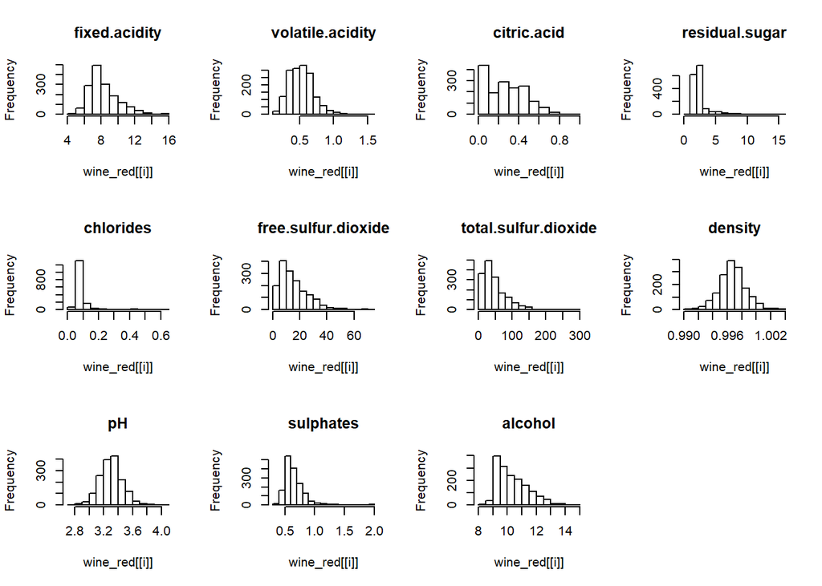

```r
par(mfrow=c(3,4))

for(i in 1:11) {
    hist(wine_red[[i]], main=names(wine_red)[i])
}
```

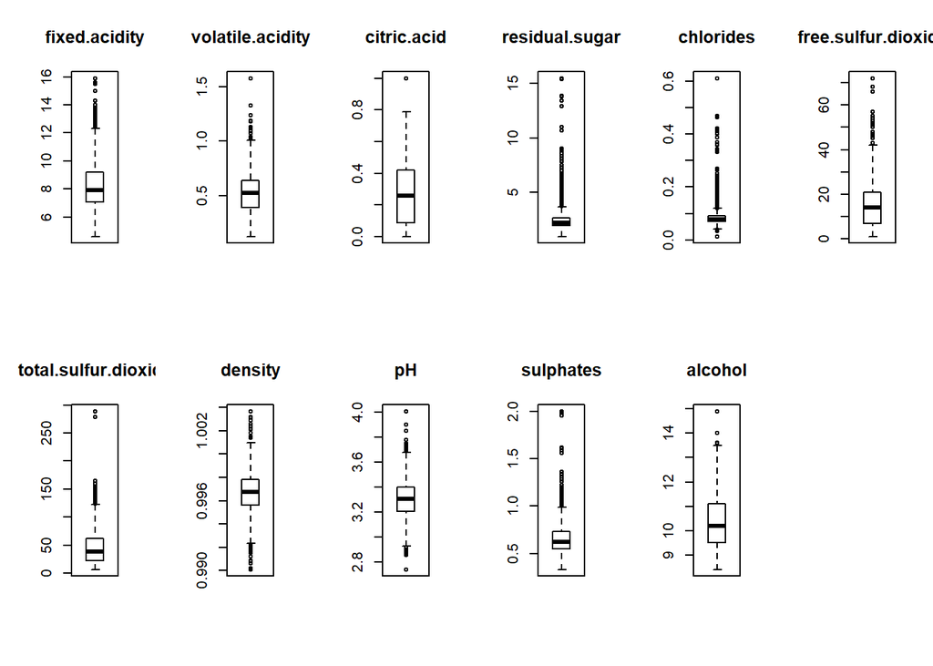

```r
par(mfrow=c(2,6))

for(i in 1:11) {
    boxplot(wine_red[[i]], main=names(wine_red)[i])
}
```

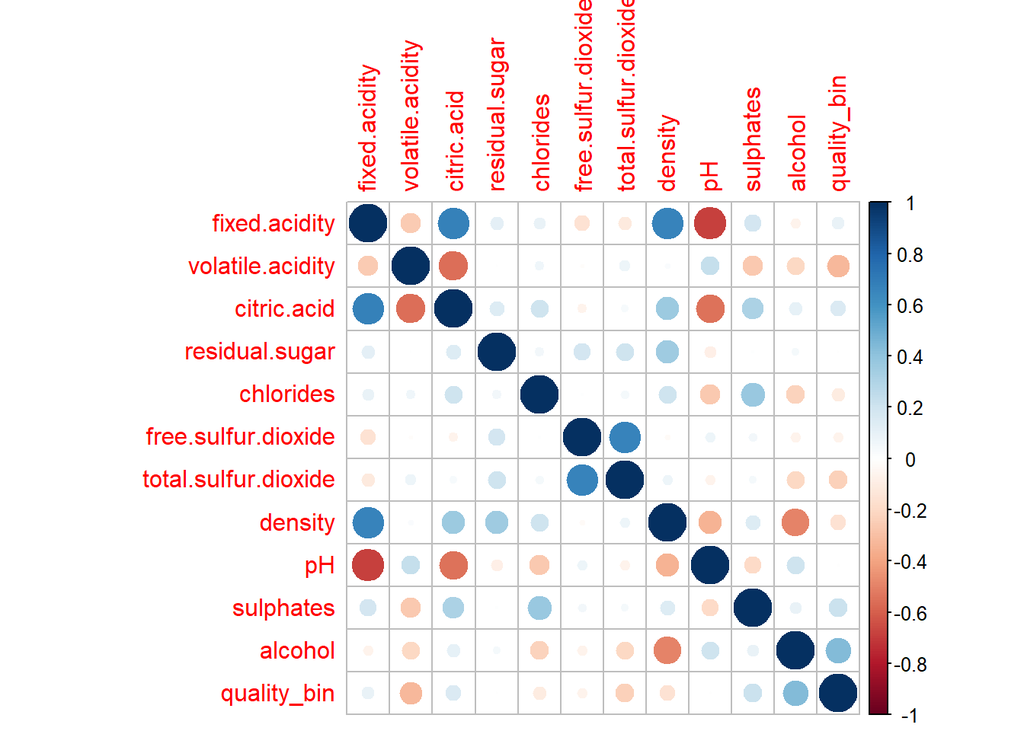

```r
library(corrplot)
# i add back in quality_bin to see what features are
# highly correlated to quality.

corr_set <- wine_red[,-12]
corr_set$quality_bin <- as.numeric(as.character(wine_red$quality_bin))
correlations <- cor(corr_set)
corrplot(correlations, method="circle")
```

```r
##pairs(wine_red, col=wine_red$quality_bin)
library(dplyr)

#wine_red$split <- sample(c(FALSE, TRUE), nrow(wine_red), replace = TRUE, prob = c(0.5, 0.5))

#train_data_ng <- wine_red %>% filter(split == TRUE) %>% select(1:12)
#test_data_ng <- wine_red %>% filter(split == FALSE) %>% select(1:12)

#length(wine_red$split[wine_red$split == TRUE])
```

```r
# unfortunately, the prior approach doesn't give me a good 50/50 split.

train_data <-  wine_red[1:800, ]
test_data <- wine_red[801:1599,]
```

```r
trained_model <- glm(formula = train_data$quality_bin ~
                    train_data$fixed.acidity +
                    train_data$volatile.acidity +
                    train_data$citric.acid +
                    train_data$residual.sugar +
                    train_data$chlorides +
                    train_data$free.sulfur.dioxide +
                    train_data$total.sulfur.dioxide +
                    train_data$density +
                    train_data$pH +
                    train_data$sulphates +
                    train_data$alcohol,
                    data = train_data,
                    family = binomial)


summary(trained_model)
```

```
##
## Call:
## glm(formula = train_data$quality_bin ~ train_data$fixed.acidity +
##     train_data$volatile.acidity + train_data$citric.acid + train_data$residual.sugar +
##     train_data$chlorides + train_data$free.sulfur.dioxide + train_data$total.sulfur.dioxide +
##     train_data$density + train_data$pH + train_data$sulphates +
##     train_data$alcohol, family = binomial, data = train_data)
##
## Deviance Residuals:
##     Min       1Q   Median       3Q      Max
## -3.1266  -0.8792  -0.3220   0.9246   2.4691
##
## Coefficients:
##                                   Estimate Std. Error z value Pr(>|z|)
## (Intercept)                      -8.103349 112.826801  -0.072  0.94274
## train_data$fixed.acidity          0.198000   0.140816   1.406  0.15970
## train_data$volatile.acidity      -3.974782   0.679417  -5.850 4.91e-09 ***
## train_data$citric.acid           -2.161458   0.776222  -2.785  0.00536 **
## train_data$residual.sugar        -0.029280   0.084911  -0.345  0.73022
## train_data$chlorides             -1.375098   1.875363  -0.733  0.46341
## train_data$free.sulfur.dioxide    0.026625   0.013596   1.958  0.05020 .
## train_data$total.sulfur.dioxide  -0.024392   0.004562  -5.347 8.92e-08 ***
## train_data$density               -2.487360 115.330392  -0.022  0.98279
## train_data$pH                     0.780841   1.000017   0.781  0.43490
## train_data$sulphates              2.269245   0.521009   4.355 1.33e-05 ***
## train_data$alcohol                0.833385   0.135778   6.138 8.37e-10 ***
## ---
## Signif. codes:  0 '***' 0.001 '**' 0.01 '*' 0.05 '.' 0.1 ' ' 1
##
## (Dispersion parameter for binomial family taken to be 1)
##
##     Null deviance: 1105.91  on 799  degrees of freedom
## Residual deviance:  852.39  on 788  degrees of freedom
## AIC: 876.39
##
## Number of Fisher Scoring iterations: 5
```

```r
# this is cleaner and simpler too.
trained_model <- glm(formula = train_data$quality_bin ~ .,
                    data = train_data, family = binomial)
summary(trained_model)
```

```
##
## Call:
## glm(formula = train_data$quality_bin ~ ., family = binomial,
##     data = train_data)
##
## Deviance Residuals:
##     Min       1Q   Median       3Q      Max
## -3.1266  -0.8792  -0.3220   0.9246   2.4691
##
## Coefficients:
##                        Estimate Std. Error z value Pr(>|z|)
## (Intercept)           -8.103349 112.826801  -0.072  0.94274
## fixed.acidity          0.198000   0.140816   1.406  0.15970
## volatile.acidity      -3.974782   0.679417  -5.850 4.91e-09 ***
## citric.acid           -2.161458   0.776222  -2.785  0.00536 **
## residual.sugar        -0.029280   0.084911  -0.345  0.73022
## chlorides             -1.375098   1.875363  -0.733  0.46341
## free.sulfur.dioxide    0.026625   0.013596   1.958  0.05020 .
## total.sulfur.dioxide  -0.024392   0.004562  -5.347 8.92e-08 ***
## density               -2.487360 115.330392  -0.022  0.98279
## pH                     0.780841   1.000017   0.781  0.43490
## sulphates              2.269245   0.521009   4.355 1.33e-05 ***
## alcohol                0.833385   0.135778   6.138 8.37e-10 ***
## ---
## Signif. codes:  0 '***' 0.001 '**' 0.01 '*' 0.05 '.' 0.1 ' ' 1
##
## (Dispersion parameter for binomial family taken to be 1)
##
##     Null deviance: 1105.91  on 799  degrees of freedom
## Residual deviance:  852.39  on 788  degrees of freedom
## AIC: 876.39
##
## Number of Fisher Scoring iterations: 5
```

```r
p_out_prob <- predict(trained_model, test_data[,-12], type = "response")

summary(p_out_prob)
```

```
##    Min. 1st Qu.  Median    Mean 3rd Qu.    Max.
##  0.0137  0.4052  0.7018  0.6195  0.8639  0.9861
```

```r
# OK, so I don't need to "drop" the response or prediction column fron the test data...
# this is a vector of prediction probability
p_out_prob <- predict(trained_model, test_data, type = "response")

summary(p_out_prob)
```

```
##    Min. 1st Qu.  Median    Mean 3rd Qu.    Max.
##  0.0137  0.4052  0.7018  0.6195  0.8639  0.9861
```

```r
library(dplyr)
p_out <- data.frame(prediction = if_else(p_out_prob < 0.5, 0, 1), quality_bin = test_data[,12])


p_out$correct <- p_out$prediction == p_out$quality_bin
head(p_out)
```

|  | prediction | quality_bin | correct |
| --- | --- | --- | --- |
| 1 | 0 | 0 | TRUE |
| 2 | 1 | 0 | FALSE |
| 3 | 1 | 1 | TRUE |
| 4 | 0 | 1 | FALSE |
| 5 | 1 | 1 | TRUE |
| 6 | 1 | 1 | TRUE |

## Classification Errors:

```r
# classification error:

cat('classification error: ', 1 - sum(p_out$correct) / (sum(p_out$correct) + sum(!p_out$correct) ))
```

```
## classification error:  0.2453066
```

```r
cat('\nclassification error: ', mean(p_out$prediction != p_out$quality_bin))
```

```
##
## classification error:  0.2453066
```

```r
cat('\n\nConfusion matrix....\n')
```

```
##
##
## Confusion matrix....
```

```r
table(p_out$prediction, test_data$quality_bin)
```

```
##
##       0   1
##   0 191  68
##   1 128 412
```

## Area Under Curve (AUC)

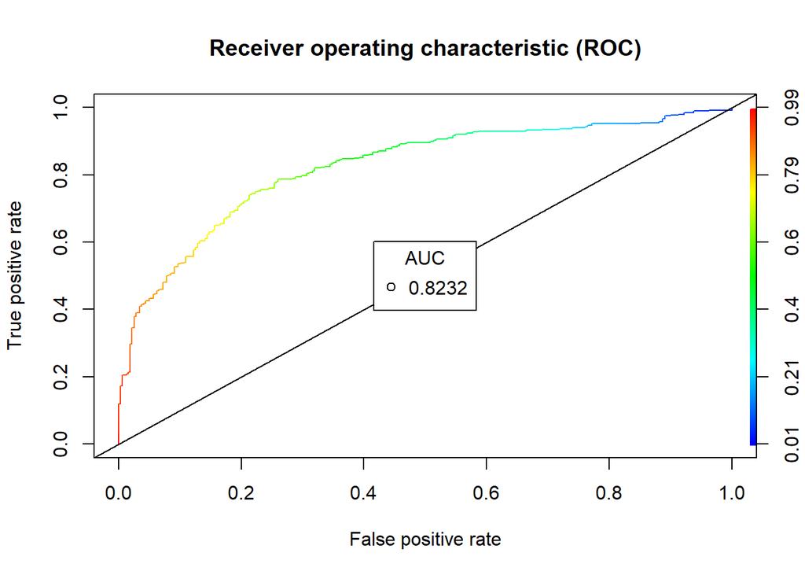

```r
library(ROCR)
pred_2 <- predict(trained_model, test_data, type = "response")
pred_3 <- prediction(pred_2, test_data$quality_bin)

auc_perf <- performance(pred_3, measure = "auc")

title_s <- paste("AUC: ", auc_perf@y.name, ":", auc_perf@y.values[[1]])

roc_perf <- performance(pred_3, measure = "tpr", x.measure = "fpr")


plot(roc_perf, colorize = TRUE)
abline(a=0, b= 1)
title('Receiver operating characteristic (ROC)')
#mtext(title_s, side=1)
s_s <- round(auc_perf@y.values[[1]],5)
legend("center", legend = s_s, pch=1, title= "AUC")
```

### Question 2

- Conduct 5-fold cross-validation using the entire training data to estimate the classification error > Q: Is it larger or smaller than the classification error you obtain in (1)?

### Response: Turns out that it was “larger” classificatin error with the 5 folds using entire dataset. What I had noticed first however is if I justed the exact same train_data set and then same test_data set I ended up with the same classification error.

> Q: Which one will be closer to the true classification error of your classifier do you think?

#### I would think that the 5 fold would be closer.

```r
library(caret)
trained_model_cross_5 <- train(
                          quality_bin ~ .,
                          data = wine_red,
                          method = 'glm',
                          family = binomial,
                          trControl = trainControl(method = 'cv', number = 5))

summary(trained_model_cross_5)
```

```
##
## Call:
## NULL
##
## Deviance Residuals:
##     Min       1Q   Median       3Q      Max
## -3.4025  -0.8387   0.3105   0.8300   2.3142
##
## Coefficients:
##                        Estimate Std. Error z value Pr(>|z|)
## (Intercept)           42.949948  79.473979   0.540  0.58890
## fixed.acidity          0.135980   0.098483   1.381  0.16736
## volatile.acidity      -3.281694   0.488214  -6.722 1.79e-11 ***
## citric.acid           -1.274347   0.562730  -2.265  0.02354 *
## residual.sugar         0.055326   0.053770   1.029  0.30351
## chlorides             -3.915713   1.569298  -2.495  0.01259 *
## free.sulfur.dioxide    0.022220   0.008236   2.698  0.00698 **
## total.sulfur.dioxide  -0.016394   0.002882  -5.688 1.29e-08 ***
## density              -50.932385  81.148745  -0.628  0.53024
## pH                    -0.380608   0.720203  -0.528  0.59717
## sulphates              2.795107   0.452184   6.181 6.36e-10 ***
## alcohol                0.866822   0.104190   8.320  < 2e-16 ***
## ---
## Signif. codes:  0 '***' 0.001 '**' 0.01 '*' 0.05 '.' 0.1 ' ' 1
##
## (Dispersion parameter for binomial family taken to be 1)
##
##     Null deviance: 2209.0  on 1598  degrees of freedom
## Residual deviance: 1655.6  on 1587  degrees of freedom
## AIC: 1679.6
##
## Number of Fisher Scoring iterations: 4
```

```r
## OK, so with this trained model, normally it outputs a 2 column data.frame
## with columns of each possible outcome (class) -- but, I only need the probabilty
## of "class == 1" as that was my factors 0 or 1.  So, the 2nd column
## this is nuances and differences in the R ecosystem amongst different libraries as well.
p_out_prob_cross <- predict(trained_model_cross_5, wine_red, type = "prob")[,2]

summary(p_out_prob_cross)
```

```
##    Min. 1st Qu.  Median    Mean 3rd Qu.    Max.
## 0.01103 0.28963 0.52581 0.53471 0.79853 0.99694
```

```r
p_out_cross <- data.frame(prediction = if_else(p_out_prob_cross < 0.5, 0, 1), quality_bin = wine_red[,12])


p_out_cross$correct <- p_out_cross$prediction == p_out_cross$quality_bin
head(p_out_cross)
```

|  | prediction | quality_bin | correct |
| --- | --- | --- | --- |
| 1 | 0 | 0 | TRUE |
| 2 | 0 | 0 | TRUE |
| 3 | 0 | 0 | TRUE |
| 4 | 1 | 1 | TRUE |
| 5 | 0 | 0 | TRUE |
| 6 | 0 | 0 | TRUE |

```r
# classification error:

cat('classification error: ', 1 - sum(p_out_cross$correct) / (sum(p_out_cross$correct) + sum(!p_out_cross$correct) ))
```

```
## classification error:  0.2557849
```

```r
cat('\nclassification error: ', mean(p_out_cross$prediction != p_out_cross$quality_bin))
```

```
##
## classification error:  0.2557849
```

```r
cat('\n\nConfusion matrix....\n')
```

```
##
##
## Confusion matrix....
```

```r
table(p_out_cross$prediction, wine_red$quality_bin)
```

```
##
##       0   1
##   0 549 214
##   1 195 641
```